# Cars4u

# Description

## Context

There is a huge demand for used cars in the Indian Market today. As sales of new cars have slowed down in the recent past, the pre-owned car market has continued to grow over the past years and is larger than the new car market now. Cars4U is a budding tech start-up that aims to find footholes in this market.

In 2018-19, while new car sales were recorded at 3.6 million units, around 4 million second-hand cars were bought and sold. There is a slowdown in new car sales and that could mean that the demand is shifting towards the pre-owned market. In fact, some car sellers replace their old cars with pre-owned cars instead of buying new ones. Unlike new cars, where price and supply are fairly deterministic and managed by OEMs (Original Equipment Manufacturer / except for dealership level discounts which come into play only in the last stage of the customer journey), used cars are very different beasts with huge uncertainty in both pricing and supply. Keeping this in mind, the pricing scheme of these used cars becomes important in order to grow in the market.

As a senior data scientist at Cars4U, you have to come up with a pricing model that can effectively predict the price of used cars and can help the business in devising profitable strategies using differential pricing. For example, if the business knows the market price, it will never sell anything below it

## Objective

To explore and visualize the dataset, build a linear regression model to predict the prices of used cars, and generate a set of insights and recommendations that will help the business.

## Problems and Questions

As stated before, the objective of this project is to build a multivariate linear regression model to predict the prices of a given set of cars. Some key problems that will be encountered in this analysis is first understanding which types of variables have an reasonable effect on the model. Another problem is seeking out the noise and the data that doesn't fit through conventional statistical summaries. This is important as just because data that doesn't seem good through the afformentioned summaries doesn't equate to a pattern that must be recognized.

Some important questions to ask are:

If data is missing, is there a possible reasoning behind its null value?

Is there a pattern to the missingness?

Does it make logical sense for specific independent variables to have the effect that they do based on the model?

What does the combination of certain values for the model performance quantities mean to the accuracy of the model?

```python
## Import statement

import numpy as np
import seaborn as sns
import matplotlib.pyplot as plt
import pandas as pd
from scipy.stats import tmean
from sklearn.preprocessing import StandardScaler, MinMaxScaler
from sklearn.preprocessing import OneHotEncoder

pd.set_option('display.max_columns', None)
pd.set_option('display.max_rows', 200)
```

```python
df = pd.read_csv('used_cars_data.csv')

df
```

|  | S.No. | Name | Location | Year | Kilometers_Driven | Fuel_Type | Transmission | Owner_Type | Mileage | Engine | Power | Seats | New_Price | Price |
| --- | --- | --- | --- | --- | --- | --- | --- | --- | --- | --- | --- | --- | --- | --- |
| 0 | 0 | Maruti Wagon R LXI CNG | Mumbai | 2010 | 72000 | CNG | Manual | First | 26.6 km/kg | 998 CC | 58.16 bhp | 5.0 | NaN | 1.75 |
| 1 | 1 | Hyundai Creta 1.6 CRDi SX Option | Pune | 2015 | 41000 | Diesel | Manual | First | 19.67 kmpl | 1582 CC | 126.2 bhp | 5.0 | NaN | 12.50 |
| 2 | 2 | Honda Jazz V | Chennai | 2011 | 46000 | Petrol | Manual | First | 18.2 kmpl | 1199 CC | 88.7 bhp | 5.0 | 8.61 Lakh | 4.50 |
| 3 | 3 | Maruti Ertiga VDI | Chennai | 2012 | 87000 | Diesel | Manual | First | 20.77 kmpl | 1248 CC | 88.76 bhp | 7.0 | NaN | 6.00 |
| 4 | 4 | Audi A4 New 2.0 TDI Multitronic | Coimbatore | 2013 | 40670 | Diesel | Automatic | Second | 15.2 kmpl | 1968 CC | 140.8 bhp | 5.0 | NaN | 17.74 |
| ... | ... | ... | ... | ... | ... | ... | ... | ... | ... | ... | ... | ... | ... | ... |
| 7248 | 7248 | Volkswagen Vento Diesel Trendline | Hyderabad | 2011 | 89411 | Diesel | Manual | First | 20.54 kmpl | 1598 CC | 103.6 bhp | 5.0 | NaN | NaN |
| 7249 | 7249 | Volkswagen Polo GT TSI | Mumbai | 2015 | 59000 | Petrol | Automatic | First | 17.21 kmpl | 1197 CC | 103.6 bhp | 5.0 | NaN | NaN |
| 7250 | 7250 | Nissan Micra Diesel XV | Kolkata | 2012 | 28000 | Diesel | Manual | First | 23.08 kmpl | 1461 CC | 63.1 bhp | 5.0 | NaN | NaN |
| 7251 | 7251 | Volkswagen Polo GT TSI | Pune | 2013 | 52262 | Petrol | Automatic | Third | 17.2 kmpl | 1197 CC | 103.6 bhp | 5.0 | NaN | NaN |
| 7252 | 7252 | Mercedes-Benz E-Class 2009-2013 E 220 CDI Avan... | Kochi | 2014 | 72443 | Diesel | Automatic | First | 10.0 kmpl | 2148 CC | 170 bhp | 5.0 | NaN | NaN |

7253 rows × 14 columns

```python
df.info()
```

```
<class 'pandas.core.frame.DataFrame'>
RangeIndex: 7253 entries, 0 to 7252
Data columns (total 14 columns):
 #   Column             Non-Null Count  Dtype
---  ------             --------------  -----
 0   S.No.              7253 non-null   int64
 1   Name               7253 non-null   object
 2   Location           7253 non-null   object
 3   Year               7253 non-null   int64
 4   Kilometers_Driven  7253 non-null   int64
 5   Fuel_Type          7253 non-null   object
 6   Transmission       7253 non-null   object
 7   Owner_Type         7253 non-null   object
 8   Mileage            7251 non-null   object
 9   Engine             7207 non-null   object
 10  Power              7078 non-null   object
 11  Seats              7200 non-null   float64
 12  New_Price          1006 non-null   object
 13  Price              6019 non-null   float64
dtypes: float64(2), int64(3), object(9)
memory usage: 793.4+ KB
```

```python
df.isnull().sum()
```

```
S.No.                   0
Name                    0
Location                0
Year                    0
Kilometers_Driven       0
Fuel_Type               0
Transmission            0
Owner_Type              0
Mileage                 2
Engine                 46
Power                 175
Seats                  53
New_Price            6247
Price                1234
dtype: int64
```

```python
df.dropna(subset = ["Price"], inplace = True)
```

```python
df
```

|  | S.No. | Name | Location | Year | Kilometers_Driven | Fuel_Type | Transmission | Owner_Type | Mileage | Engine | Power | Seats | New_Price | Price |
| --- | --- | --- | --- | --- | --- | --- | --- | --- | --- | --- | --- | --- | --- | --- |
| 0 | 0 | Maruti Wagon R LXI CNG | Mumbai | 2010 | 72000 | CNG | Manual | First | 26.6 km/kg | 998 CC | 58.16 bhp | 5.0 | NaN | 1.75 |
| 1 | 1 | Hyundai Creta 1.6 CRDi SX Option | Pune | 2015 | 41000 | Diesel | Manual | First | 19.67 kmpl | 1582 CC | 126.2 bhp | 5.0 | NaN | 12.50 |
| 2 | 2 | Honda Jazz V | Chennai | 2011 | 46000 | Petrol | Manual | First | 18.2 kmpl | 1199 CC | 88.7 bhp | 5.0 | 8.61 Lakh | 4.50 |
| 3 | 3 | Maruti Ertiga VDI | Chennai | 2012 | 87000 | Diesel | Manual | First | 20.77 kmpl | 1248 CC | 88.76 bhp | 7.0 | NaN | 6.00 |
| 4 | 4 | Audi A4 New 2.0 TDI Multitronic | Coimbatore | 2013 | 40670 | Diesel | Automatic | Second | 15.2 kmpl | 1968 CC | 140.8 bhp | 5.0 | NaN | 17.74 |
| ... | ... | ... | ... | ... | ... | ... | ... | ... | ... | ... | ... | ... | ... | ... |
| 6014 | 6014 | Maruti Swift VDI | Delhi | 2014 | 27365 | Diesel | Manual | First | 28.4 kmpl | 1248 CC | 74 bhp | 5.0 | 7.88 Lakh | 4.75 |
| 6015 | 6015 | Hyundai Xcent 1.1 CRDi S | Jaipur | 2015 | 100000 | Diesel | Manual | First | 24.4 kmpl | 1120 CC | 71 bhp | 5.0 | NaN | 4.00 |
| 6016 | 6016 | Mahindra Xylo D4 BSIV | Jaipur | 2012 | 55000 | Diesel | Manual | Second | 14.0 kmpl | 2498 CC | 112 bhp | 8.0 | NaN | 2.90 |
| 6017 | 6017 | Maruti Wagon R VXI | Kolkata | 2013 | 46000 | Petrol | Manual | First | 18.9 kmpl | 998 CC | 67.1 bhp | 5.0 | NaN | 2.65 |
| 6018 | 6018 | Chevrolet Beat Diesel | Hyderabad | 2011 | 47000 | Diesel | Manual | First | 25.44 kmpl | 936 CC | 57.6 bhp | 5.0 | NaN | 2.50 |

6019 rows × 14 columns

```python
df['New_Price'].isnull().sum()
```

```
5195
```

```python
df.isnull().sum().sort_values()
```

```
S.No.                   0
Name                    0
Location                0
Year                    0
Kilometers_Driven       0
Fuel_Type               0
Transmission            0
Owner_Type              0
Price                   0
Mileage                 2
Engine                 36
Seats                  42
Power                 143
New_Price            5195
dtype: int64
```

```python
df = df.drop(["New_Price"],axis = 1)
```

```python
df.isnull().sum()
```

```
S.No.                  0
Name                   0
Location               0
Year                   0
Kilometers_Driven      0
Fuel_Type              0
Transmission           0
Owner_Type             0
Mileage                2
Engine                36
Power                143
Seats                 42
Price                  0
dtype: int64
```

```python
df
```

|  | S.No. | Name | Location | Year | Kilometers_Driven | Fuel_Type | Transmission | Owner_Type | Mileage | Engine | Power | Seats | Price |
| --- | --- | --- | --- | --- | --- | --- | --- | --- | --- | --- | --- | --- | --- |
| 0 | 0 | Maruti Wagon R LXI CNG | Mumbai | 2010 | 72000 | CNG | Manual | First | 26.6 km/kg | 998 CC | 58.16 bhp | 5.0 | 1.75 |
| 1 | 1 | Hyundai Creta 1.6 CRDi SX Option | Pune | 2015 | 41000 | Diesel | Manual | First | 19.67 kmpl | 1582 CC | 126.2 bhp | 5.0 | 12.50 |
| 2 | 2 | Honda Jazz V | Chennai | 2011 | 46000 | Petrol | Manual | First | 18.2 kmpl | 1199 CC | 88.7 bhp | 5.0 | 4.50 |
| 3 | 3 | Maruti Ertiga VDI | Chennai | 2012 | 87000 | Diesel | Manual | First | 20.77 kmpl | 1248 CC | 88.76 bhp | 7.0 | 6.00 |
| 4 | 4 | Audi A4 New 2.0 TDI Multitronic | Coimbatore | 2013 | 40670 | Diesel | Automatic | Second | 15.2 kmpl | 1968 CC | 140.8 bhp | 5.0 | 17.74 |
| ... | ... | ... | ... | ... | ... | ... | ... | ... | ... | ... | ... | ... | ... |
| 6014 | 6014 | Maruti Swift VDI | Delhi | 2014 | 27365 | Diesel | Manual | First | 28.4 kmpl | 1248 CC | 74 bhp | 5.0 | 4.75 |
| 6015 | 6015 | Hyundai Xcent 1.1 CRDi S | Jaipur | 2015 | 100000 | Diesel | Manual | First | 24.4 kmpl | 1120 CC | 71 bhp | 5.0 | 4.00 |
| 6016 | 6016 | Mahindra Xylo D4 BSIV | Jaipur | 2012 | 55000 | Diesel | Manual | Second | 14.0 kmpl | 2498 CC | 112 bhp | 8.0 | 2.90 |
| 6017 | 6017 | Maruti Wagon R VXI | Kolkata | 2013 | 46000 | Petrol | Manual | First | 18.9 kmpl | 998 CC | 67.1 bhp | 5.0 | 2.65 |
| 6018 | 6018 | Chevrolet Beat Diesel | Hyderabad | 2011 | 47000 | Diesel | Manual | First | 25.44 kmpl | 936 CC | 57.6 bhp | 5.0 | 2.50 |

6019 rows × 13 columns

## Column Preprocessing and Feautre Selection

We first need to translate as many columns into numeric columns

```python
## Mileage Conversion

df.dtypes['Mileage']


def mileage_to_num(mileage_str):
    multiplier = 1
    if str(mileage_str).endswith("km/kg"):
        multiplier = 1.40
    elif str(mileage_str).endswith("kmpl"):
        multiplier = 1
    return float(str(mileage_str).replace("km/kg","").replace("kmpl",""))*multiplier


test = '36 km/kg'

mileage_to_num(test)


## Mileage in numeric values variable with units kmpl
mileage_kmpl = []


for i in df['Mileage']:
    mileage_kmpl.append(mileage_to_num(i))

mileage_kmpl
df['Mileage'] = mileage_kmpl
```

```python
## Engine Conversion
i = None

for i in df['Engine']:
    df['Engine'] = df['Engine'].replace(i,float(str(i).replace("CC","")))

df['Engine']
```

```
0        998.0
1       1582.0
2       1199.0
3       1248.0
4       1968.0
         ...
6014    1248.0
6015    1120.0
6016    2498.0
6017     998.0
6018     936.0
Name: Engine, Length: 6019, dtype: float64
```

```python
## checks the location in which the engine values is less than 1000
df['Engine'].loc[df['Engine'] < 1000]
```

```
0       998.0
5       814.0
27      998.0
40      796.0
41      624.0
        ...
5966    998.0
5997    998.0
6003    998.0
6017    998.0
6018    936.0
Name: Engine, Length: 588, dtype: float64
```

```python
## Power Conversion
i = None

for i in df['Power']:
    df['Power'] = df['Power'].replace(i,float(str(i).replace("bhp","")))

df['Power']
```

```
0        58.16
1       126.20
2        88.70
3        88.76
4       140.80
         ...
6014     74.00
6015     71.00
6016    112.00
6017     67.10
6018     57.60
Name: Power, Length: 6019, dtype: float64
```

```python
df = df.rename(columns = {"Mileage":"Mileage_kmpl", "Engine":"Engine_CC", "Power":"Power_bhp", "Price":"Price_Lahk"})

df
```

|  | S.No. | Name | Location | Year | Kilometers_Driven | Fuel_Type | Transmission | Owner_Type | Mileage_kmpl | Engine_CC | Power_bhp | Seats | Price_Lahk |
| --- | --- | --- | --- | --- | --- | --- | --- | --- | --- | --- | --- | --- | --- |
| 0 | 0 | Maruti Wagon R LXI CNG | Mumbai | 2010 | 72000 | CNG | Manual | First | 37.24 | 998.0 | 58.16 | 5.0 | 1.75 |
| 1 | 1 | Hyundai Creta 1.6 CRDi SX Option | Pune | 2015 | 41000 | Diesel | Manual | First | 19.67 | 1582.0 | 126.20 | 5.0 | 12.50 |
| 2 | 2 | Honda Jazz V | Chennai | 2011 | 46000 | Petrol | Manual | First | 18.20 | 1199.0 | 88.70 | 5.0 | 4.50 |
| 3 | 3 | Maruti Ertiga VDI | Chennai | 2012 | 87000 | Diesel | Manual | First | 20.77 | 1248.0 | 88.76 | 7.0 | 6.00 |
| 4 | 4 | Audi A4 New 2.0 TDI Multitronic | Coimbatore | 2013 | 40670 | Diesel | Automatic | Second | 15.20 | 1968.0 | 140.80 | 5.0 | 17.74 |
| ... | ... | ... | ... | ... | ... | ... | ... | ... | ... | ... | ... | ... | ... |
| 6014 | 6014 | Maruti Swift VDI | Delhi | 2014 | 27365 | Diesel | Manual | First | 28.40 | 1248.0 | 74.00 | 5.0 | 4.75 |
| 6015 | 6015 | Hyundai Xcent 1.1 CRDi S | Jaipur | 2015 | 100000 | Diesel | Manual | First | 24.40 | 1120.0 | 71.00 | 5.0 | 4.00 |
| 6016 | 6016 | Mahindra Xylo D4 BSIV | Jaipur | 2012 | 55000 | Diesel | Manual | Second | 14.00 | 2498.0 | 112.00 | 8.0 | 2.90 |
| 6017 | 6017 | Maruti Wagon R VXI | Kolkata | 2013 | 46000 | Petrol | Manual | First | 18.90 | 998.0 | 67.10 | 5.0 | 2.65 |
| 6018 | 6018 | Chevrolet Beat Diesel | Hyderabad | 2011 | 47000 | Diesel | Manual | First | 25.44 | 936.0 | 57.60 | 5.0 | 2.50 |

6019 rows × 13 columns

```python
df.isnull().sum().sort_values()
```

```
S.No.                  0
Name                   0
Location               0
Year                   0
Kilometers_Driven      0
Fuel_Type              0
Transmission           0
Owner_Type             0
Price_Lahk             0
Mileage_kmpl           2
Engine_CC             36
Seats                 42
Power_bhp            143
dtype: int64
```

The next step is to drop all the null values as they're is no logical reasoning for a car to have a null value in any of those categories. Also, there doesn't seem to be a pattern behind the missingness so it's fair to drop the.

```python
df_clean1 = df.dropna()
df_clean1
```

|  | S.No. | Name | Location | Year | Kilometers_Driven | Fuel_Type | Transmission | Owner_Type | Mileage_kmpl | Engine_CC | Power_bhp | Seats | Price_Lahk |
| --- | --- | --- | --- | --- | --- | --- | --- | --- | --- | --- | --- | --- | --- |
| 0 | 0 | Maruti Wagon R LXI CNG | Mumbai | 2010 | 72000 | CNG | Manual | First | 37.24 | 998.0 | 58.16 | 5.0 | 1.75 |
| 1 | 1 | Hyundai Creta 1.6 CRDi SX Option | Pune | 2015 | 41000 | Diesel | Manual | First | 19.67 | 1582.0 | 126.20 | 5.0 | 12.50 |
| 2 | 2 | Honda Jazz V | Chennai | 2011 | 46000 | Petrol | Manual | First | 18.20 | 1199.0 | 88.70 | 5.0 | 4.50 |
| 3 | 3 | Maruti Ertiga VDI | Chennai | 2012 | 87000 | Diesel | Manual | First | 20.77 | 1248.0 | 88.76 | 7.0 | 6.00 |
| 4 | 4 | Audi A4 New 2.0 TDI Multitronic | Coimbatore | 2013 | 40670 | Diesel | Automatic | Second | 15.20 | 1968.0 | 140.80 | 5.0 | 17.74 |
| ... | ... | ... | ... | ... | ... | ... | ... | ... | ... | ... | ... | ... | ... |
| 6014 | 6014 | Maruti Swift VDI | Delhi | 2014 | 27365 | Diesel | Manual | First | 28.40 | 1248.0 | 74.00 | 5.0 | 4.75 |
| 6015 | 6015 | Hyundai Xcent 1.1 CRDi S | Jaipur | 2015 | 100000 | Diesel | Manual | First | 24.40 | 1120.0 | 71.00 | 5.0 | 4.00 |
| 6016 | 6016 | Mahindra Xylo D4 BSIV | Jaipur | 2012 | 55000 | Diesel | Manual | Second | 14.00 | 2498.0 | 112.00 | 8.0 | 2.90 |
| 6017 | 6017 | Maruti Wagon R VXI | Kolkata | 2013 | 46000 | Petrol | Manual | First | 18.90 | 998.0 | 67.10 | 5.0 | 2.65 |
| 6018 | 6018 | Chevrolet Beat Diesel | Hyderabad | 2011 | 47000 | Diesel | Manual | First | 25.44 | 936.0 | 57.60 | 5.0 | 2.50 |

5872 rows × 13 columns

## Basic summary statistics and consequences

```python
df_clean1.describe().T #quick summary of numeric features
```

|  | count | mean | std | min | 25% | 50% | 75% | max |
| --- | --- | --- | --- | --- | --- | --- | --- | --- |
| S.No. | 5872.0 | 3013.288147 | 1737.351187 | 0.00 | 1509.7500 | 3015.50 | 4516.25 | 6018.000 |
| Year | 5872.0 | 2013.477691 | 3.164568 | 1998.00 | 2012.0000 | 2014.00 | 2016.00 | 2019.000 |
| Kilometers_Driven | 5872.0 | 58316.999149 | 92169.410006 | 171.00 | 33422.5000 | 52609.00 | 72402.75 | 6500000.000 |
| Mileage_kmpl | 5872.0 | 18.386848 | 4.680325 | 0.00 | 15.2900 | 18.33 | 21.10 | 46.956 |
| Engine_CC | 5872.0 | 1625.745572 | 601.641783 | 624.00 | 1198.0000 | 1495.50 | 1991.00 | 5998.000 |
| Power_bhp | 5872.0 | 113.276894 | 53.881892 | 34.20 | 75.0000 | 97.70 | 138.10 | 560.000 |
| Seats | 5872.0 | 5.283719 | 0.805081 | 2.00 | 5.0000 | 5.00 | 5.00 | 10.000 |
| Price_Lahk | 5872.0 | 9.603919 | 11.249453 | 0.44 | 3.5175 | 5.75 | 10.00 | 160.000 |

[output not shown]

[output cut: 11 more lines]

[output not shown]

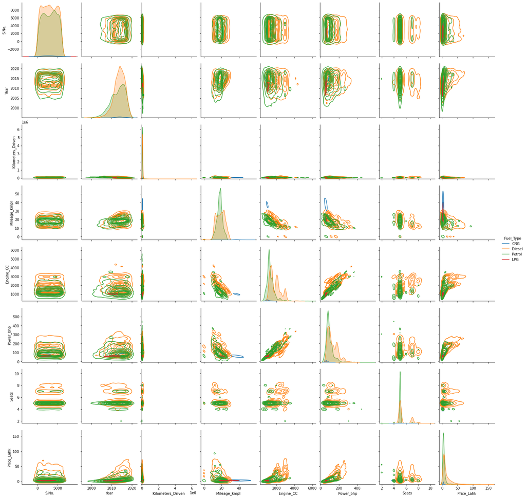

```python
sns.pairplot(df_clean1,hue = 'Fuel_Type', kind = "kde")
```

## Univariate Analysis

Distribution plots of all Numeric Variables

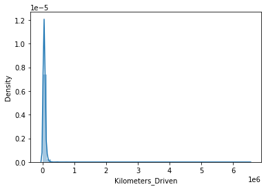

```python
# Kilometers Driven
sns.distplot(df_clean1['Kilometers_Driven'])
```

The distribution for Kilometers driven is heavily skewed and since there aren't any negative valuse, applying log scale would be an effective measure

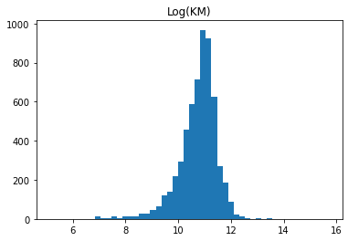

```python
# Kilometer Driven in Log Scaling
plt.hist(np.log(df_clean1['Kilometers_Driven']),50);
plt.title('Log(KM)')
plt.show()
```

The log plot shifted the distrubtion to the right and allows for a more normal distribution.

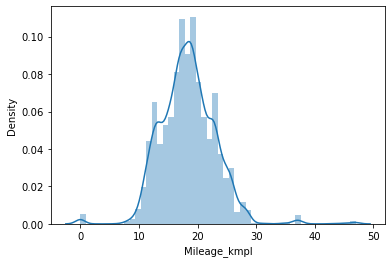

```python
# Mileage_kmpl
sns.distplot(df_clean1['Mileage_kmpl'])
```

The distribution for mileage already seems pretty evenly distributed.

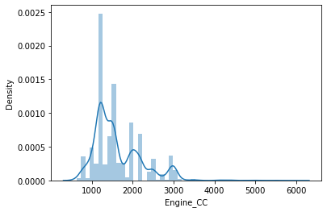

```python
# Engine CC

sns.distplot(df_clean1['Engine_CC'])
```

The distribution is slightly skewed to the right. Let's try to apply log scaling as this column also doesn't contain any negative value as the power output in this context can't be negative.

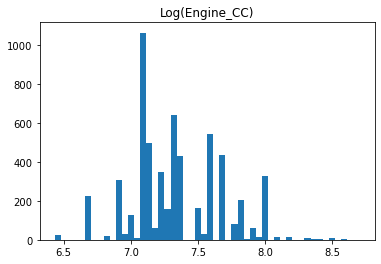

```python
# Engine CC Log Scaling
plt.hist(np.log(df_clean1['Engine_CC']),50)
plt.title('Log(Engine_CC)')
plt.show()
```

This plot has an uncontinous curve for the distribution but it does have a more centered distribution.

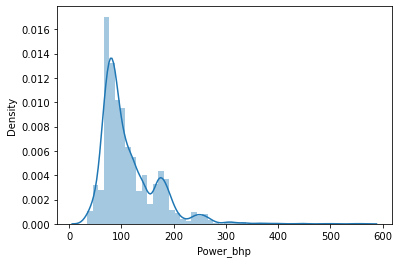

```python
# Power bhp
sns.distplot(df_clean1['Power_bhp'])
```

Let's apply Log Scaling to this curve as well.

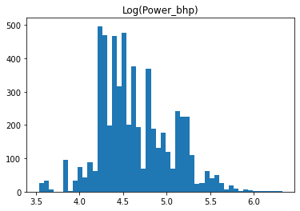

```python
plt.hist(np.log(df_clean1['Power_bhp']),50)
plt.title('Log(Power_bhp)')
plt.show()
```

A more centered distribution.

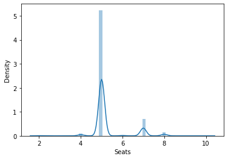

```python
# Seats
sns.distplot(df_clean1['Seats'])
```

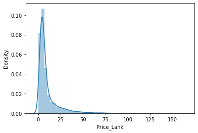

```python
#Price
sns.distplot(df_clean1['Price_Lahk'])
```

This plot doesn't need to be centered back as this is the target column that we are trying to plot.

## Model Building and Bivariate Analysis

Let's first look at the correlation differences between the orginial data and the log transform distribution.

```python
## Change this to experiment

df_clean1
```

|  | S.No. | Name | Location | Year | Kilometers_Driven | Fuel_Type | Transmission | Owner_Type | Mileage_kmpl | Engine_CC | Power_bhp | Seats | Price_Lahk |
| --- | --- | --- | --- | --- | --- | --- | --- | --- | --- | --- | --- | --- | --- |
| 0 | 0 | Maruti Wagon R LXI CNG | Mumbai | 2010 | 72000 | CNG | Manual | First | 37.24 | 998.0 | 58.16 | 5.0 | 1.75 |
| 1 | 1 | Hyundai Creta 1.6 CRDi SX Option | Pune | 2015 | 41000 | Diesel | Manual | First | 19.67 | 1582.0 | 126.20 | 5.0 | 12.50 |
| 2 | 2 | Honda Jazz V | Chennai | 2011 | 46000 | Petrol | Manual | First | 18.20 | 1199.0 | 88.70 | 5.0 | 4.50 |
| 3 | 3 | Maruti Ertiga VDI | Chennai | 2012 | 87000 | Diesel | Manual | First | 20.77 | 1248.0 | 88.76 | 7.0 | 6.00 |
| 4 | 4 | Audi A4 New 2.0 TDI Multitronic | Coimbatore | 2013 | 40670 | Diesel | Automatic | Second | 15.20 | 1968.0 | 140.80 | 5.0 | 17.74 |
| ... | ... | ... | ... | ... | ... | ... | ... | ... | ... | ... | ... | ... | ... |
| 6014 | 6014 | Maruti Swift VDI | Delhi | 2014 | 27365 | Diesel | Manual | First | 28.40 | 1248.0 | 74.00 | 5.0 | 4.75 |
| 6015 | 6015 | Hyundai Xcent 1.1 CRDi S | Jaipur | 2015 | 100000 | Diesel | Manual | First | 24.40 | 1120.0 | 71.00 | 5.0 | 4.00 |
| 6016 | 6016 | Mahindra Xylo D4 BSIV | Jaipur | 2012 | 55000 | Diesel | Manual | Second | 14.00 | 2498.0 | 112.00 | 8.0 | 2.90 |
| 6017 | 6017 | Maruti Wagon R VXI | Kolkata | 2013 | 46000 | Petrol | Manual | First | 18.90 | 998.0 | 67.10 | 5.0 | 2.65 |
| 6018 | 6018 | Chevrolet Beat Diesel | Hyderabad | 2011 | 47000 | Diesel | Manual | First | 25.44 | 936.0 | 57.60 | 5.0 | 2.50 |

5872 rows × 13 columns

```python
## Log Data Frame
df_clean2 = df_clean1.copy(deep = True)

df_clean2['Kilometers_Driven'] = np.log(df_clean2['Kilometers_Driven'])
df_clean2['Engine_CC'] = np.log(df_clean2['Engine_CC'])
df_clean2['Power_bhp'] = np.log(df_clean2['Power_bhp'])
df_clean2['Seats'] = np.log(df_clean2['Seats'])
df_clean2['Price_Lahk'] = np.log(df_clean2['Price_Lahk']*100000)
df_clean2 = df_clean2.rename(columns = {'Kilometers_Driven' : 'Kilometers_Driven_log', 'Engine_CC': 'Engine_CC_log', 'Power_bhp':'Power_bhp_log', 'Seats':'Seats_log','Price_Lahk':'Price_Rupees_Log'})

df_clean2
```

|  | S.No. | Name | Location | Year | Kilometers_Driven_log | Fuel_Type | Transmission | Owner_Type | Mileage_kmpl | Engine_CC_log | Power_bhp_log | Seats_log | Price_Rupees_Log |
| --- | --- | --- | --- | --- | --- | --- | --- | --- | --- | --- | --- | --- | --- |
| 0 | 0 | Maruti Wagon R LXI CNG | Mumbai | 2010 | 11.184421 | CNG | Manual | First | 37.24 | 6.905753 | 4.063198 | 1.609438 | 12.072541 |
| 1 | 1 | Hyundai Creta 1.6 CRDi SX Option | Pune | 2015 | 10.621327 | Diesel | Manual | First | 19.67 | 7.366445 | 4.837868 | 1.609438 | 14.038654 |
| 2 | 2 | Honda Jazz V | Chennai | 2011 | 10.736397 | Petrol | Manual | First | 18.20 | 7.089243 | 4.485260 | 1.609438 | 13.017003 |
| 3 | 3 | Maruti Ertiga VDI | Chennai | 2012 | 11.373663 | Diesel | Manual | First | 20.77 | 7.129298 | 4.485936 | 1.945910 | 13.304685 |
| 4 | 4 | Audi A4 New 2.0 TDI Multitronic | Coimbatore | 2013 | 10.613246 | Diesel | Automatic | Second | 15.20 | 7.584773 | 4.947340 | 1.609438 | 14.388747 |
| ... | ... | ... | ... | ... | ... | ... | ... | ... | ... | ... | ... | ... | ... |
| 6014 | 6014 | Maruti Swift VDI | Delhi | 2014 | 10.217020 | Diesel | Manual | First | 28.40 | 7.129298 | 4.304065 | 1.609438 | 13.071070 |
| 6015 | 6015 | Hyundai Xcent 1.1 CRDi S | Jaipur | 2015 | 11.512925 | Diesel | Manual | First | 24.40 | 7.021084 | 4.262680 | 1.609438 | 12.899220 |
| 6016 | 6016 | Mahindra Xylo D4 BSIV | Jaipur | 2012 | 10.915088 | Diesel | Manual | Second | 14.00 | 7.823246 | 4.718499 | 2.079442 | 12.577636 |
| 6017 | 6017 | Maruti Wagon R VXI | Kolkata | 2013 | 10.736397 | Petrol | Manual | First | 18.90 | 6.905753 | 4.206184 | 1.609438 | 12.487485 |
| 6018 | 6018 | Chevrolet Beat Diesel | Hyderabad | 2011 | 10.757903 | Diesel | Manual | First | 25.44 | 6.841615 | 4.053523 | 1.609438 | 12.429216 |

5872 rows × 13 columns

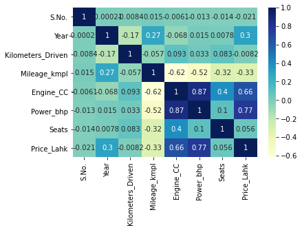

```python
cormat = df_clean1.corr()
sns.heatmap(cormat, annot = True, cmap = "YlGnBu")
```

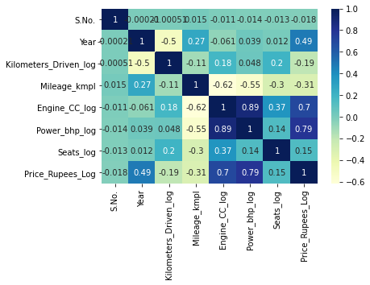

```python
cormat_log = df_clean2.corr()
sns.heatmap(cormat_log, annot = True, cmap = "YlGnBu")
```

```python
df_clean2 = df_clean2.drop(["Name"], axis = 1)
df_clean2 = df_clean2.drop(["S.No."], axis = 1)

df_clean2
```

|  | Location | Year | Kilometers_Driven_log | Fuel_Type | Transmission | Owner_Type | Mileage_kmpl | Engine_CC_log | Power_bhp_log | Seats_log | Price_Rupees_Log |
| --- | --- | --- | --- | --- | --- | --- | --- | --- | --- | --- | --- |
| 0 | Mumbai | 2010 | 11.184421 | CNG | Manual | First | 37.24 | 6.905753 | 4.063198 | 1.609438 | 12.072541 |
| 1 | Pune | 2015 | 10.621327 | Diesel | Manual | First | 19.67 | 7.366445 | 4.837868 | 1.609438 | 14.038654 |
| 2 | Chennai | 2011 | 10.736397 | Petrol | Manual | First | 18.20 | 7.089243 | 4.485260 | 1.609438 | 13.017003 |
| 3 | Chennai | 2012 | 11.373663 | Diesel | Manual | First | 20.77 | 7.129298 | 4.485936 | 1.945910 | 13.304685 |
| 4 | Coimbatore | 2013 | 10.613246 | Diesel | Automatic | Second | 15.20 | 7.584773 | 4.947340 | 1.609438 | 14.388747 |
| ... | ... | ... | ... | ... | ... | ... | ... | ... | ... | ... | ... |
| 6014 | Delhi | 2014 | 10.217020 | Diesel | Manual | First | 28.40 | 7.129298 | 4.304065 | 1.609438 | 13.071070 |
| 6015 | Jaipur | 2015 | 11.512925 | Diesel | Manual | First | 24.40 | 7.021084 | 4.262680 | 1.609438 | 12.899220 |
| 6016 | Jaipur | 2012 | 10.915088 | Diesel | Manual | Second | 14.00 | 7.823246 | 4.718499 | 2.079442 | 12.577636 |
| 6017 | Kolkata | 2013 | 10.736397 | Petrol | Manual | First | 18.90 | 6.905753 | 4.206184 | 1.609438 | 12.487485 |
| 6018 | Hyderabad | 2011 | 10.757903 | Diesel | Manual | First | 25.44 | 6.841615 | 4.053523 | 1.609438 | 12.429216 |

5872 rows × 11 columns

```python
df_clean2['Location'].value_counts()
```

```
Mumbai        775
Hyderabad     718
Kochi         645
Coimbatore    629
Pune          594
Delhi         545
Kolkata       521
Chennai       476
Jaipur        402
Bangalore     347
Ahmedabad     220
Name: Location, dtype: int64
```

## Define Dependent variable

```python
X = df_clean2.drop('Price_Rupees_Log', axis = 1)
y = df_clean2['Price_Rupees_Log']
```

## Create Dummy Variables

```python
X = pd.get_dummies(
    X, columns = X.select_dtypes(include = ["object","category"]).columns.tolist(),
    drop_first = True
)

X
```

|  | Year | Kilometers_Driven_log | Mileage_kmpl | Engine_CC_log | Power_bhp_log | Seats_log | Location_Bangalore | Location_Chennai | Location_Coimbatore | Location_Delhi | Location_Hyderabad | Location_Jaipur | Location_Kochi | Location_Kolkata | Location_Mumbai | Location_Pune | Fuel_Type_Diesel | Fuel_Type_LPG | Fuel_Type_Petrol | Transmission_Manual | Owner_Type_Fourth & Above | Owner_Type_Second | Owner_Type_Third |
| --- | --- | --- | --- | --- | --- | --- | --- | --- | --- | --- | --- | --- | --- | --- | --- | --- | --- | --- | --- | --- | --- | --- | --- |
| 0 | 2010 | 11.184421 | 37.24 | 6.905753 | 4.063198 | 1.609438 | 0 | 0 | 0 | 0 | 0 | 0 | 0 | 0 | 1 | 0 | 0 | 0 | 0 | 1 | 0 | 0 | 0 |
| 1 | 2015 | 10.621327 | 19.67 | 7.366445 | 4.837868 | 1.609438 | 0 | 0 | 0 | 0 | 0 | 0 | 0 | 0 | 0 | 1 | 1 | 0 | 0 | 1 | 0 | 0 | 0 |
| 2 | 2011 | 10.736397 | 18.20 | 7.089243 | 4.485260 | 1.609438 | 0 | 1 | 0 | 0 | 0 | 0 | 0 | 0 | 0 | 0 | 0 | 0 | 1 | 1 | 0 | 0 | 0 |
| 3 | 2012 | 11.373663 | 20.77 | 7.129298 | 4.485936 | 1.945910 | 0 | 1 | 0 | 0 | 0 | 0 | 0 | 0 | 0 | 0 | 1 | 0 | 0 | 1 | 0 | 0 | 0 |
| 4 | 2013 | 10.613246 | 15.20 | 7.584773 | 4.947340 | 1.609438 | 0 | 0 | 1 | 0 | 0 | 0 | 0 | 0 | 0 | 0 | 1 | 0 | 0 | 0 | 0 | 1 | 0 |
| ... | ... | ... | ... | ... | ... | ... | ... | ... | ... | ... | ... | ... | ... | ... | ... | ... | ... | ... | ... | ... | ... | ... | ... |
| 6014 | 2014 | 10.217020 | 28.40 | 7.129298 | 4.304065 | 1.609438 | 0 | 0 | 0 | 1 | 0 | 0 | 0 | 0 | 0 | 0 | 1 | 0 | 0 | 1 | 0 | 0 | 0 |
| 6015 | 2015 | 11.512925 | 24.40 | 7.021084 | 4.262680 | 1.609438 | 0 | 0 | 0 | 0 | 0 | 1 | 0 | 0 | 0 | 0 | 1 | 0 | 0 | 1 | 0 | 0 | 0 |
| 6016 | 2012 | 10.915088 | 14.00 | 7.823246 | 4.718499 | 2.079442 | 0 | 0 | 0 | 0 | 0 | 1 | 0 | 0 | 0 | 0 | 1 | 0 | 0 | 1 | 0 | 1 | 0 |
| 6017 | 2013 | 10.736397 | 18.90 | 6.905753 | 4.206184 | 1.609438 | 0 | 0 | 0 | 0 | 0 | 0 | 0 | 1 | 0 | 0 | 0 | 0 | 1 | 1 | 0 | 0 | 0 |
| 6018 | 2011 | 10.757903 | 25.44 | 6.841615 | 4.053523 | 1.609438 | 0 | 0 | 0 | 0 | 1 | 0 | 0 | 0 | 0 | 0 | 1 | 0 | 0 | 1 | 0 | 0 | 0 |

5872 rows × 23 columns

## Split Data

```python
from sklearn.model_selection import train_test_split

x_train, x_test, y_train, y_test = train_test_split(X, y, test_size = 0.3, random_state = 1)
```

```python
print("Train Rows:" + str(x_train.shape[0]))
print("Test Rows:" + str(x_test.shape[0]))
```

```
Train Rows:4110
Test Rows:1762
```

### Fitting the Model

```python
from sklearn.linear_model import LinearRegression
from sklearn.metrics import mean_absolute_error, mean_squared_error, r2_score
```

```python
lin_reg_model = LinearRegression()
lin_reg_model.fit(x_train, y_train)
```

```
LinearRegression()
```

### Coefficients and Intercept of the model, which are the parameter from the train

```python
coef_df = pd.DataFrame(
    np.append(lin_reg_model.coef_, lin_reg_model.intercept_),
    index=x_train.columns.tolist() + ["Intercept"],
    columns=["Coefficients"],
)
coef_df
```

|  | Coefficients |
| --- | --- |
| Year | 0.108921 |
| Kilometers_Driven_log | -0.096239 |
| Mileage_kmpl | -0.011565 |
| Engine_CC_log | 0.296729 |
| Power_bhp_log | 1.024508 |
| Seats_log | -0.133573 |
| Location_Bangalore | 0.148040 |
| Location_Chennai | 0.014256 |
| Location_Coimbatore | 0.116983 |
| Location_Delhi | -0.055057 |
| Location_Hyderabad | 0.125922 |
| Location_Jaipur | -0.048745 |
| Location_Kochi | -0.022095 |
| Location_Kolkata | -0.233459 |
| Location_Mumbai | -0.083842 |
| Location_Pune | -0.056520 |
| Fuel_Type_Diesel | -0.101703 |
| Fuel_Type_LPG | -0.089793 |
| Fuel_Type_Petrol | -0.390465 |
| Transmission_Manual | -0.287509 |
| Owner_Type_Fourth & Above | 0.046386 |
| Owner_Type_Second | -0.077628 |
| Owner_Type_Third | -0.074421 |
| Intercept | -210.953050 |

```python
# function to compute adjusted R-squared
def adj_r2_score(predictors, targets, predictions):
    r2 = r2_score(targets, predictions)
    n = predictors.shape[0]
    k = predictors.shape[1]
    return 1 - ((1 - r2) * (n - 1) / (n - k - 1))


# function to compute MAPE
def mape_score(targets, predictions):
    return np.mean(np.abs(targets - predictions) / targets) * 100


# function to compute different metrics to check performance of a regression model
def model_performance_regression(model, predictors, target):
    """
    Function to compute different metrics to check regression model performance

    model: regressor
    predictors: independent variables
    target: dependent variable
    """

    # predicting using the independent variables
    pred = model.predict(predictors)

    r2 = r2_score(target, pred)  # to compute R-squared
    adjr2 = adj_r2_score(predictors, target, pred)  # to compute adjusted R-squared
    rmse = np.sqrt(mean_squared_error(target, pred))  # to compute RMSE
    mae = mean_absolute_error(target, pred)  # to compute MAE
    mape = mape_score(target, pred)  # to compute MAPE

    # creating a dataframe of metrics
    df_perf = pd.DataFrame(
        {
            "RMSE": rmse,
            "MAE": mae,
            "R-squared": r2,
            "Adj. R-squared": adjr2,
            "MAPE": mape,
        },
        index=[0],
    )

    return df_perf
```

```python
# Checking model performance on train set
print("Training Performance\n")
lin_reg_model_train_perf = model_performance_regression(lin_reg_model, x_train, y_train)
lin_reg_model_train_perf
```

```
Training Performance
```

|  | RMSE | MAE | R-squared | Adj. R-squared | MAPE |
| --- | --- | --- | --- | --- | --- |
| 0 | 0.289099 | 0.217957 | 0.889996 | 0.889377 | 1.639266 |

```python
# Checking model performance on test set
print("Testing Performance\n")
lin_reg_model_test_perf = model_performance_regression(lin_reg_model, x_test, y_test)
lin_reg_model_test_perf
```

```
Testing Performance
```

|  | RMSE | MAE | R-squared | Adj. R-squared | MAPE |
| --- | --- | --- | --- | --- | --- |
| 0 | 0.277698 | 0.215335 | 0.892143 | 0.890715 | 1.618817 |

## Conclusions and Observations

The RSME values for both the training and testing set are comparable indicating that there isn't much overfit or underfit of the modeling.

The adjusted R-squared values for training and testing are also comparable, which shows that the input variables have a significant contribution on the out/dependent variable.

MAE is another form of forecasting error of predicted values from observed values.

## Recommendations

Based off this multivariate regression model, it seems to provide a decent to good prediction on car prices based on location, power, engine, fuel type, and transmission type. As a consumer, it seems ideal to purchase a car based on economic needs and personal preference. If the goal is to purchase a suitable and economic car, the consumer would ideally be frugal on the power output of the car as that coefficient has the highest positive effect on the Price based on the regression trend. It also seems viable to look into which cities one could purchase it from and the fuel type as that also has a big effect on reducing price of a car. As a vendor or a seller, it should be imperitive to understand the power ouput and the fuel type, as a high end fuel type has a pretty low decrease coefficient on the price. It should also be noted that vehicles in India seem to be heavily influenced by how strong it is. As an advertiser, it would be wise to look into ways to market the vehicles they sell as a tough and reliable vehicle.